# Lab 8 — t-tests & Categorical Variables

Quantitative Reasoning · LAB 413

Instructor: Subin Na

October 29, 2025

> **How to use this document.** Run the code along with me. Comments start with `#`. Each section mirrors the live lab; code chunks show the command and its output together.

**Today’s plan**

1. Clean environment + setup
2. Import & understand Life Expectancy data
3. Working with categorical variables
4. One-sample *t*-test (Life Expectancy)
5. Two-sample *t*-test (Developed vs. Developing)
6. Quick practice
7. Wrap-up

# 1 Clean Environment + Setup

```r
rm(list = ls())   # clean environment

# Load the packages
library(dplyr)
library(ggplot2)
library(stats)
```

> In the live session we set the working directory with `setwd(...)`. In this document the data file `Life Expectancy Data.csv` sits next to the `.Rmd`, so no `setwd()` is needed.

# 2 Import & Understand Data

The dataset is the WHO **Life Expectancy** data.

```r
data <- read.csv("Life Expectancy Data.csv")

# In RStudio you would run View(data); here we preview the first rows.
knitr::kable(head(data), caption = "First rows of the Life Expectancy data")
```

First rows of the Life Expectancy data

| Country | Year | Status | Life.expectancy | Adult.Mortality | infant.deaths | Alcohol | percentage.expenditure | Hepatitis.B | Measles | BMI | under.five.deaths | Polio | Total.expenditure | Diphtheria | HIV.AIDS | GDP | Population | thinness..1.19.years | thinness.5.9.years | Income.composition.of.resources | Schooling |
| --- | --- | --- | --- | --- | --- | --- | --- | --- | --- | --- | --- | --- | --- | --- | --- | --- | --- | --- | --- | --- | --- |
| Afghanistan | 2015 | Developing | 65.0 | 263 | 62 | 0.01 | 71.279624 | 65 | 1154 | 19.1 | 83 | 6 | 8.16 | 65 | 0.1 | 584.25921 | 33736494 | 17.2 | 17.3 | 0.479 | 10.1 |
| Afghanistan | 2014 | Developing | 59.9 | 271 | 64 | 0.01 | 73.523582 | 62 | 492 | 18.6 | 86 | 58 | 8.18 | 62 | 0.1 | 612.69651 | 327582 | 17.5 | 17.5 | 0.476 | 10.0 |
| Afghanistan | 2013 | Developing | 59.9 | 268 | 66 | 0.01 | 73.219243 | 64 | 430 | 18.1 | 89 | 62 | 8.13 | 64 | 0.1 | 631.74498 | 31731688 | 17.7 | 17.7 | 0.470 | 9.9 |
| Afghanistan | 2012 | Developing | 59.5 | 272 | 69 | 0.01 | 78.184215 | 67 | 2787 | 17.6 | 93 | 67 | 8.52 | 67 | 0.1 | 669.95900 | 3696958 | 17.9 | 18.0 | 0.463 | 9.8 |
| Afghanistan | 2011 | Developing | 59.2 | 275 | 71 | 0.01 | 7.097109 | 68 | 3013 | 17.2 | 97 | 68 | 7.87 | 68 | 0.1 | 63.53723 | 2978599 | 18.2 | 18.2 | 0.454 | 9.5 |
| Afghanistan | 2010 | Developing | 58.8 | 279 | 74 | 0.01 | 79.679367 | 66 | 1989 | 16.7 | 102 | 66 | 9.20 | 66 | 0.1 | 553.32894 | 2883167 | 18.4 | 18.4 | 0.448 | 9.2 |

```r
summary(data)
```

```
#>    Country               Year         Status          Life.expectancy
#>  Length:2938        Min.   :2000   Length:2938        Min.   :36.30
#>  Class :character   1st Qu.:2004   Class :character   1st Qu.:63.10
#>  Mode  :character   Median :2008   Mode  :character   Median :72.10
#>                     Mean   :2008                      Mean   :69.22
#>                     3rd Qu.:2012                      3rd Qu.:75.70
#>                     Max.   :2015                      Max.   :89.00
#>                                                       NA's   :10
#>  Adult.Mortality infant.deaths       Alcohol        percentage.expenditure
#>  Min.   :  1.0   Min.   :   0.0   Min.   : 0.0100   Min.   :    0.000
#>  1st Qu.: 74.0   1st Qu.:   0.0   1st Qu.: 0.8775   1st Qu.:    4.685
#>  Median :144.0   Median :   3.0   Median : 3.7550   Median :   64.913
#>  Mean   :164.8   Mean   :  30.3   Mean   : 4.6029   Mean   :  738.251
#>  3rd Qu.:228.0   3rd Qu.:  22.0   3rd Qu.: 7.7025   3rd Qu.:  441.534
#>  Max.   :723.0   Max.   :1800.0   Max.   :17.8700   Max.   :19479.912
#>  NA's   :10                       NA's   :194
#>   Hepatitis.B       Measles              BMI        under.five.deaths
#>  Min.   : 1.00   Min.   :     0.0   Min.   : 1.00   Min.   :   0.00
#>  1st Qu.:77.00   1st Qu.:     0.0   1st Qu.:19.30   1st Qu.:   0.00
#>  Median :92.00   Median :    17.0   Median :43.50   Median :   4.00
#>  Mean   :80.94   Mean   :  2419.6   Mean   :38.32   Mean   :  42.04
#>  3rd Qu.:97.00   3rd Qu.:   360.2   3rd Qu.:56.20   3rd Qu.:  28.00
#>  Max.   :99.00   Max.   :212183.0   Max.   :87.30   Max.   :2500.00
#>  NA's   :553                        NA's   :34
#>      Polio       Total.expenditure   Diphtheria       HIV.AIDS
#>  Min.   : 3.00   Min.   : 0.370    Min.   : 2.00   Min.   : 0.100
#>  1st Qu.:78.00   1st Qu.: 4.260    1st Qu.:78.00   1st Qu.: 0.100
#>  Median :93.00   Median : 5.755    Median :93.00   Median : 0.100
#>  Mean   :82.55   Mean   : 5.938    Mean   :82.32   Mean   : 1.742
#>  3rd Qu.:97.00   3rd Qu.: 7.492    3rd Qu.:97.00   3rd Qu.: 0.800
#>  Max.   :99.00   Max.   :17.600    Max.   :99.00   Max.   :50.600
#>  NA's   :19      NA's   :226       NA's   :19
#>       GDP              Population        thinness..1.19.years
#>  Min.   :     1.68   Min.   :3.400e+01   Min.   : 0.10
#>  1st Qu.:   463.94   1st Qu.:1.958e+05   1st Qu.: 1.60
#>  Median :  1766.95   Median :1.387e+06   Median : 3.30
#>  Mean   :  7483.16   Mean   :1.275e+07   Mean   : 4.84
#>  3rd Qu.:  5910.81   3rd Qu.:7.420e+06   3rd Qu.: 7.20
#>  Max.   :119172.74   Max.   :1.294e+09   Max.   :27.70
#>  NA's   :448         NA's   :652         NA's   :34
#>  thinness.5.9.years Income.composition.of.resources   Schooling
#>  Min.   : 0.10      Min.   :0.0000                  Min.   : 0.00
#>  1st Qu.: 1.50      1st Qu.:0.4930                  1st Qu.:10.10
#>  Median : 3.30      Median :0.6770                  Median :12.30
#>  Mean   : 4.87      Mean   :0.6276                  Mean   :11.99
#>  3rd Qu.: 7.20      3rd Qu.:0.7790                  3rd Qu.:14.30
#>  Max.   :28.60      Max.   :0.9480                  Max.   :20.70
#>  NA's   :34         NA's   :167                     NA's   :163
```

# 3 Categorical Variables

**What is recoding / encoding?** Converting categorical variables (text) into numeric values — for example, `"Developed"` → 1 and `"Developing"` → 0.

**Why do we recode?**

- Regression models need numeric predictors.
- It makes categorical data usable in statistical tests.

**Create a dummy variable.** Use `ifelse()` for binary variables.

```r
data$is_developed <- ifelse(data$Status == "Developed", 1, 0)
head(data$is_developed)
```

```
#> [1] 0 0 0 0 0 0
```

**Simple regression with a binary predictor.** Predict life expectancy from developed/developing status.

```r
model1 <- lm(Life.expectancy ~ is_developed, data = data)
summary(model1)
```

```
#>
#> Call:
#> lm(formula = Life.expectancy ~ is_developed, data = data)
#>
#> Residuals:
#>     Min      1Q  Median      3Q     Max
#> -30.811  -4.912   1.288   6.489  21.889
#>
#> Coefficients:
#>              Estimate Std. Error t value Pr(>|t|)
#> (Intercept)   67.1115     0.1698  395.28   <2e-16 ***
#> is_developed  12.0864     0.4060   29.77   <2e-16 ***
#> ---
#> Signif. codes:  0 '***' 0.001 '**' 0.01 '*' 0.05 '.' 0.1 ' ' 1
#>
#> Residual standard error: 8.345 on 2926 degrees of freedom
#>   (10 observations deleted due to missingness)
#> Multiple R-squared:  0.2325, Adjusted R-squared:  0.2322
#> F-statistic: 886.2 on 1 and 2926 DF,  p-value: < 2.2e-16
```

> - **Intercept** = mean life expectancy for Developing countries (the reference group).
> - **`is_developed`** = difference in mean life expectancy (Developed − Developing).

# 4 One-Sample t-test (Life Expectancy)

We test $H_0: \mu = 70$ against $H_1: \mu \neq 70$.

**Step 1 — Sample mean.**

```r
mean(data$Life.expectancy, na.rm = TRUE)
```

```
#> [1] 69.22493
```

**Step 2 — One-sample *t*-test.**

```r
t.test(data$Life.expectancy, mu = 70)
```

```
#>
#>  One Sample t-test
#>
#> data:  data$Life.expectancy
#> t = -4.4036, df = 2927, p-value = 1.103e-05
#> alternative hypothesis: true mean is not equal to 70
#> 95 percent confidence interval:
#>  68.87982 69.57004
#> sample estimates:
#> mean of x
#>  69.22493
```

**Step 3 — Extract the 95% CI bounds** (for plotting).

```r
ci_life <- t.test(data$Life.expectancy, conf.level = 0.95)$conf.int
ci_life
```

```
#> [1] 68.87982 69.57004
#> attr(,"conf.level")
#> [1] 0.95
```

**Step 4 — Visualize the distribution with CI lines.**

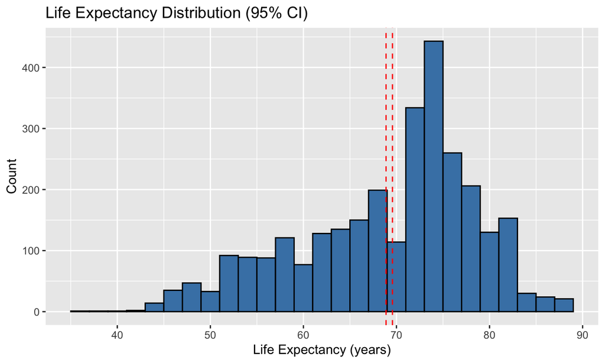

```r
ggplot(data, aes(x = Life.expectancy)) +
  geom_histogram(binwidth = 2, fill = "steelblue", color = "black") +
  geom_vline(xintercept = ci_life, linetype = "dashed", color = "red") +
  labs(
    title = "Life Expectancy Distribution (95% CI)",
    x = "Life Expectancy (years)",
    y = "Count"
  )
```

# 5 Two-Sample t-test (Developed vs. Developing)

We test $H_0: \mu_{\text{developed}} = \mu_{\text{developing}}$ against $H_1: \mu_{\text{developed}} \neq \mu_{\text{developing}}$.

```r
t.test(Life.expectancy ~ Status, data = data)
```

```
#>
#>  Welch Two Sample t-test
#>
#> data:  Life.expectancy by Status
#> t = 47.868, df = 1807, p-value < 2.2e-16
#> alternative hypothesis: true difference in means between group Developed and group Developing is not equal to 0
#> 95 percent confidence interval:
#>  11.59118 12.58159
#> sample estimates:
#>  mean in group Developed mean in group Developing
#>                 79.19785                 67.11147
```

> In `t.test(y ~ x, data = ...)`:
> - `y` = numeric variable (the thing you’re measuring)
> - `x` = categorical variable (the grouping factor, must have 2 levels)

**Visualize.**

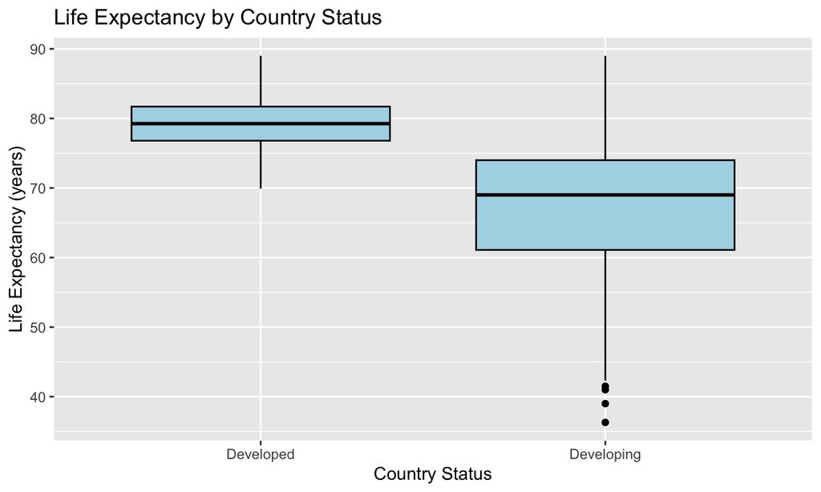

```r
ggplot(data, aes(x = Status, y = Life.expectancy)) +
  geom_boxplot(fill = "lightblue", color = "black") +
  labs(
    title = "Life Expectancy by Country Status",
    x = "Country Status",
    y = "Life Expectancy (years)"
  )
```

# 6 Quick Practice

**P1) One-sample *t*-test: is average GDP different from 5000?**

```r
t.test(data$GDP, mu = 5000)
```

```
#>
#>  One Sample t-test
#>
#> data:  data$GDP
#> t = 8.6831, df = 2489, p-value < 2.2e-16
#> alternative hypothesis: true mean is not equal to 5000
#> 95 percent confidence interval:
#>  6922.383 8043.934
#> sample estimates:
#> mean of x
#>  7483.158
```

**P2) One-sample *t*-test: is average `Schooling` different from 10?** Create a histogram with the 95% CI.

```r
t.test(data$Schooling, mu = 10)
```

```
#>
#>  One Sample t-test
#>
#> data:  data$Schooling
#> t = 31.253, df = 2774, p-value < 2.2e-16
#> alternative hypothesis: true mean is not equal to 10
#> 95 percent confidence interval:
#>  11.86777 12.11782
#> sample estimates:
#> mean of x
#>  11.99279
```

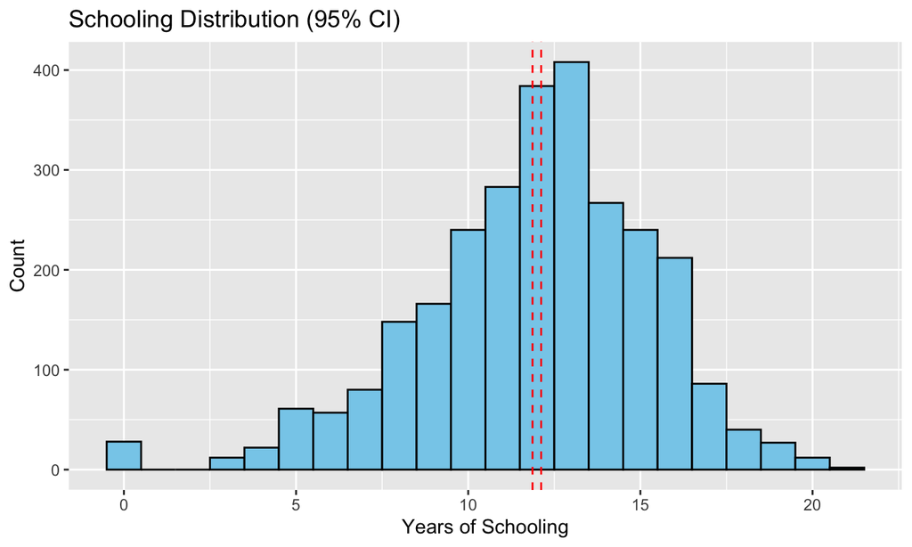

```r
ci_schooling <- t.test(data$Schooling, conf.level = 0.95)$conf.int

ggplot(data, aes(x = Schooling)) +
  geom_histogram(binwidth = 1, fill = "skyblue", color = "black") +
  geom_vline(xintercept = ci_schooling, linetype = "dashed", color = "red") +
  labs(
    title = "Schooling Distribution (95% CI)",
    x = "Years of Schooling",
    y = "Count"
  )
```

**P3) Two-sample *t*-test: compare `Adult.Mortality` between Developed and Developing.** Create boxplots by group.

```r
t.test(Adult.Mortality ~ Status, data = data)
```

```
#>
#>  Welch Two Sample t-test
#>
#> data:  Adult.Mortality by Status
#> t = -30.745, df = 2174.9, p-value < 2.2e-16
#> alternative hypothesis: true difference in means between group Developed and group Developing is not equal to 0
#> 95 percent confidence interval:
#>  -109.72693  -96.56836
#> sample estimates:
#>  mean in group Developed mean in group Developing
#>                 79.68555                182.83320
```

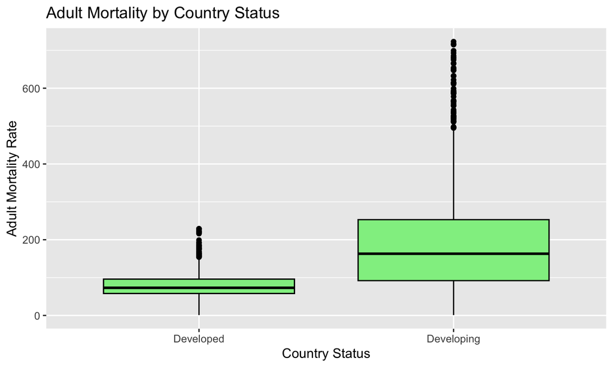

```r
ggplot(data, aes(x = Status, y = Adult.Mortality)) +
  geom_boxplot(fill = "lightgreen", color = "black") +
  labs(
    title = "Adult Mortality by Country Status",
    x = "Country Status",
    y = "Adult Mortality Rate"
  )
```

# 7 Wrap-up

**Key takeaways**

- Use `ifelse()` to create binary (dummy) variables.
- Use `t.test(x, mu = value)` for a one-sample test.
- Use `t.test(y ~ x, data)` for two independent samples.
- Extract the CI with `$conf.int`, then draw vertical lines on histograms.
- Visualize distributions and group comparisons with **ggplot2**.